# HipHop Lyrics

Harshal Suryawanshi

2022-11-13

```r
library(tidyverse)
library(here)
```

```r
library(ggplot2)
```

# The Data

```r
hiphop_data <- read_csv(here("Data", "hiphop.csv"))
summarise(hiphop_data)
```

```
## # A tibble: 1 × 0
```

# Cleaning the dataset

```r
hiphop_data <- hiphop_data %>%
  mutate(
    sex = as.factor(sex),
    ethnic = as.factor(ethnic))
```

# Unique AAVE words studied in this dataset

```r
length(unique(hiphop_data[["word"]]))
```

```
## [1] 64
```

- There are 64 unique AAE words in this dataset

# Recategoriging ethnic into only two groups, “white” and “non-white”, to simplify data

```r
hiphop_data <- hiphop_data %>%
  mutate(
   ethnicity = ifelse(ethnic == "white", "white", "non-white")
  )
```

# Demographics of the people in this study. Investigating the variables sex, age, and ethnic and summarize our findings

```r
hiphop_demo <- hiphop_data %>%
  select(sex, subj, age, ethnic)

hiphop_demo1 <- unique(hiphop_demo)
summary(hiphop_demo1)
```

```
##      sex          subj                age             ethnic
##  Female:117   Length:168         Min.   :16.00   white   :135
##  Male  : 51   Class :character   1st Qu.:18.00   asian   : 19
##               Mode  :character   Median :19.00   african :  5
##                                  Mean   :20.02   hispanic:  3
##                                  3rd Qu.:20.00   indian  :  2
##                                  Max.   :48.00   biracial:  1
##                                                  (Other) :  3
```

- The demographics of the people in this study shows that there are 117 females and 51 males with maximum age among the participants being 48 while minimum being 16. Participants include people with different ethinicity which include White, Asian, Hispanic, Indian and Birarcial. White people contribute to the maximum percentage of the population.

# Plots to display the demographic information of the subjects in this study

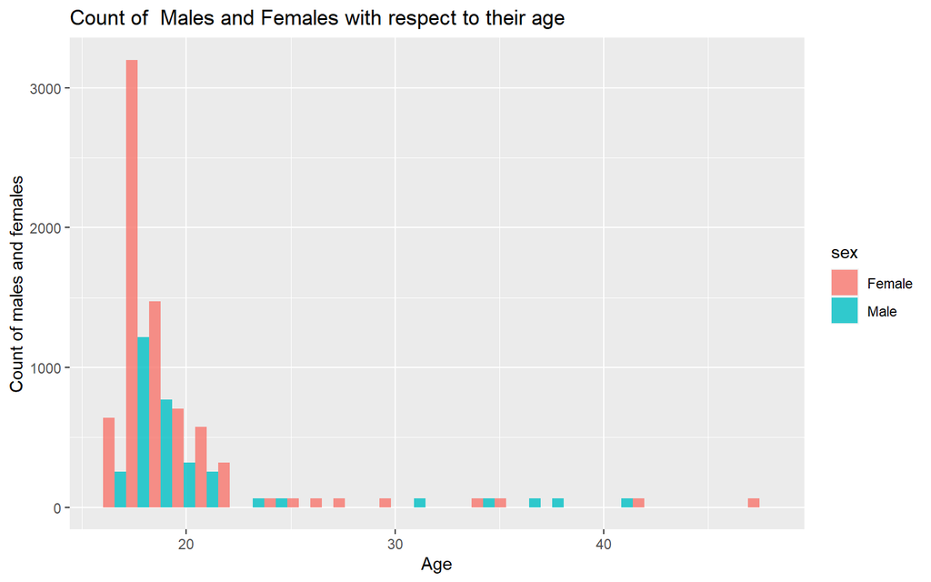

```r
hiphop_data %>%
  ggplot(aes(x = age, fill = sex)) + geom_histogram(position = "dodge", alpha=0.8) + labs(x = "Age", y = "Count of males and females") + ggtitle("Count of  Males and Females with respect to their age")
```

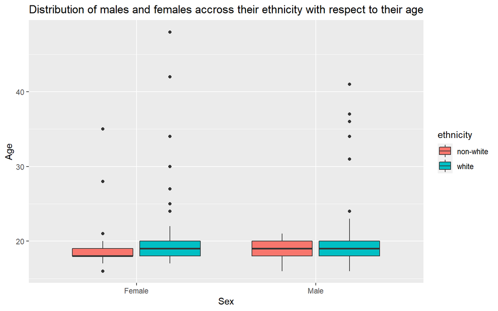

```r
hiphop_data %>%
  ggplot(aes(x= sex, y = age, fill = ethnicity)) + geom_boxplot() + labs(x = "Sex", y = "Age") + ggtitle("Distribution of males and females accross their ethnicity with respect to their age")
```

# Determining which word(s) in this study was the most and least familiar on average for each demographic group

## **People below the age of 20**

```r
FamiliarWords <- hiphop_data %>%
  select(word, age, familiarity) %>%
  filter(age < 20) %>%
  group_by(word) %>%
  summarize(mean_familiarity = mean(familiarity))
```

```r
FamiliarWords %>% top_n(1)
```

```
## # A tibble: 1 × 2
##   word         mean_familiarity
##   <chr>                   <dbl>
## 1 off the hook             4.42
```

```r
FamiliarWords %>% top_n(-1)
```

```
## # A tibble: 1 × 2
##   word             mean_familiarity
##   <chr>                       <dbl>
## 1 catch the vapors             1.03
```

- Most popular word for people below age of 20 is **off the hook** and Least popular word for people below age of 20 is **catch the vapors**

## Non-white women

```r
FamiliarWords <- hiphop_data %>%
  select(word, sex, ethnicity, familiarity) %>%
  filter(sex == "Female", ethnicity == "non-white") %>%
  group_by(word) %>%
  summarize(mean_familiarity = mean(familiarity))
```

```r
FamiliarWords %>% top_n(1)
```

```
## # A tibble: 1 × 2
##   word    mean_familiarity
##   <chr>              <dbl>
## 1 feel me             4.19
```

```r
FamiliarWords %>% top_n(-1)
```

```
## # A tibble: 4 × 2
##   word              mean_familiarity
##   <chr>                        <dbl>
## 1 break someone out                1
## 2 dukey rope                       1
## 3 plex                             1
## 4 rollie                           1
```

- The most popular word among non-white women is **feel me** and the least popular words among non-white women are **break someone out**, **dukey rope**, **plex**, **rollie**.

## White men above the age of 30

```r
FamiliarWords <- hiphop_data %>%
  select(word, sex, age, ethnicity, familiarity) %>%
  filter(sex == "Male", ethnicity == "white", age > 30) %>%
  group_by(word) %>%
  summarize(mean_familiarity = mean(familiarity))
  FamiliarWords
```

```
## # A tibble: 64 × 2
##    word          mean_familiarity
##    <chr>                    <dbl>
##  1 [to be] ghost              2.6
##  2 5-0                        4.2
##  3 A-town                     3.4
##  4 ashy                       2.6
##  5 ay yo trip                 1
##  6 ballin'                    2.8
##  7 beezy                      1
##  8 bones                      2.6
##  9 boo                        2
## 10 boughie                    1.8
## # … with 54 more rows
## # ℹ Use `print(n = ...)` to see more rows
```

```r
FamiliarWords %>% top_n(1)
```

```
## # A tibble: 1 × 2
##   word  mean_familiarity
##   <chr>            <dbl>
## 1 5-0                4.2
```

```r
FamiliarWords %>% top_n(-1)
```

```
## # A tibble: 25 × 2
##    word              mean_familiarity
##    <chr>                        <dbl>
##  1 ay yo trip                       1
##  2 beezy                            1
##  3 break someone out                1
##  4 catch the vapors                 1
##  5 crossroads                       1
##  6 crump                            1
##  7 dap                              1
##  8 dollar cab                       1
##  9 domino                           1
## 10 duckets                          1
## # … with 15 more rows
## # ℹ Use `print(n = ...)` to see more rows
```

# Determining which music genre most differentiates the groups for each demographic. That is, which genre had much higher average (mean or median) score in one group than the other

## Male versus Female

```r
hiphop_data1 <- hiphop_data %>%
  select(intl:unclassifiable, sex) %>%
  group_by(sex) %>%
  summarise(across(intl:unclassifiable, list(mean)))

hiphop_data1 <- setNames(data.frame(t(hiphop_data1[ , - 1])), hiphop_data1[ , 1])
colnames(hiphop_data1) = c("Female", "Male")

hiphop_data1 %>%
  mutate(Difference = Female - Male) %>%
  arrange(hiphop_data1)
```

```
##                      Female       Male   Difference
## unclassifiable_1 0.05982906 0.03921569  0.020613374
## folk_1           0.40170940 0.39215686  0.009552539
## intl_1           0.44444444 0.25490196  0.189542484
## classical_1      0.75213675 0.94117647 -0.189039718
## country_1        0.78632479 0.39215686  0.394167924
## vocal_1          0.88034188 1.56862745 -0.688285571
## pop_1            1.29914530 1.09803922  0.201106083
## hiphop_1         1.62393162 1.52941176  0.094519859
## rock_1           1.93162393 3.05882353 -1.127199598
## alternative_1    2.21367521 2.15686275  0.056812469
```

- **Rock** genre has much higher average in male than female

## White versus Non-White

```r
hiphop_data1 <- hiphop_data %>%
  select(intl:unclassifiable, ethnicity) %>%
  group_by(ethnicity) %>%
  summarise(across(intl:unclassifiable, list(mean)))

hiphop_data1 <- setNames(data.frame(t(hiphop_data1[ , - 1])), hiphop_data1[ , 1])
colnames(hiphop_data1) = c("non_white", "white")

hiphop_data1 %>%
  mutate(Difference = non_white - white) %>%
  arrange(hiphop_data1)
```

```
##                   non_white      white  Difference
## unclassifiable_1 0.09090909 0.04444444  0.04646465
## folk_1           0.18181818 0.45185185 -0.27003367
## country_1        0.27272727 0.76296296 -0.49023569
## vocal_1          0.66666667 1.19259259 -0.52592593
## classical_1      0.84848485 0.80000000  0.04848485
## rock_1           1.06060606 2.57037037 -1.50976431
## alternative_1    1.24242424 2.42962963 -1.18720539
## pop_1            1.27272727 1.22962963  0.04309764
## intl_1           1.66666667 0.07407407  1.59259259
## hiphop_1         2.18181818 1.45185185  0.72996633
```

- **International Music** has a higher average in non-white people than white people.

## Age below 21 versus age 21+

```r
hiphop_data1 <- hiphop_data %>%
  select(intl:unclassifiable, age) %>%
  mutate(age_group = case_when(age < 21 ~ "below 21", age >= 21 ~ "above 21")) %>%
  group_by(age_group) %>%
  summarise(across(intl:unclassifiable, mean))

hiphop_data1 <- setNames(data.frame(t(hiphop_data1[ , - 1])), hiphop_data1[ , 1])
colnames(hiphop_data1) = c("above 21", "below 21")

hiphop_data1 %>%
  mutate(Difference =  `above 21` - `below 21`) %>%
  arrange(hiphop_data1)
```

```
##                  above 21   below 21  Difference
## unclassifiable 0.08823529 0.04477612  0.04345917
## intl           0.11764706 0.45522388 -0.33757682
## folk           0.41176471 0.39552239  0.01624232
## country        0.67647059 0.66417910  0.01229148
## classical      0.88235294 0.79104478  0.09130817
## vocal          0.94117647 1.12686567 -0.18568920
## pop            1.20588235 1.24626866 -0.04038630
## hiphop         1.35294118 1.65671642 -0.30377524
## rock           2.32352941 2.26119403  0.06233538
## alternative    2.50000000 2.11940299  0.38059701
```

- **Alternative** has the highest average among people aged above 21 than those having age below 21.

# Finding words which could be used and avoided in a song which will be percieved as authentically hiphop. Lyrics will be recognizeable to those who describe themselves as hiphop fans, but less recognizeable to those who do not consider themselves fans

```r
A_data <- hiphop_data %>%
  select(word, hiphop, familiarity)

summary(A_data)
```

```
##      word               hiphop        familiarity
##  Length:10752       Min.   : 0.000   Min.   :1.000
##  Class :character   1st Qu.: 0.000   1st Qu.:1.000
##  Mode  :character   Median : 0.000   Median :1.000
##                     Mean   : 1.595   Mean   :1.818
##                     3rd Qu.: 3.000   3rd Qu.:1.000
##                     Max.   :10.000   Max.   :5.000
```

```r
A_data <- A_data %>%
  mutate(hiphop = ifelse(hiphop > 3, "fans", "non-fans")) %>%
  group_by(hiphop, word) %>%
  summarize(mean_familiarity= mean(familiarity))
fans<- A_data %>%
  filter(hiphop == "fans", mean_familiarity >= 3)
fans
```

```
## # A tibble: 10 × 3
## # Groups:   hiphop [1]
##    hiphop word         mean_familiarity
##    <chr>  <chr>                   <dbl>
##  1 fans   5-0                      3
##  2 fans   ashy                     3.22
##  3 fans   boo                      3.91
##  4 fans   feel me                  4.5
##  5 fans   finna                    3.59
##  6 fans   hella                    4.31
##  7 fans   make it rain             3.66
##  8 fans   off the hook             4.31
##  9 fans   what it do               3.81
## 10 fans   What it is?              3.44
```

```r
non_fans <- A_data %>%
  filter(hiphop == "non-fans", mean_familiarity >= 3)
non_fans
```

```
## # A tibble: 4 × 3
## # Groups:   hiphop [1]
##   hiphop   word         mean_familiarity
##   <chr>    <chr>                   <dbl>
## 1 non-fans boo                      3.42
## 2 non-fans feel me                  4.16
## 3 non-fans hella                    3.56
## 4 non-fans off the hook             4.32
```

```r
anti_join(fans, non_fans, by = "word")
```

```
## # A tibble: 6 × 3
## # Groups:   hiphop [1]
##   hiphop word         mean_familiarity
##   <chr>  <chr>                   <dbl>
## 1 fans   5-0                      3
## 2 fans   ashy                     3.22
## 3 fans   finna                    3.59
## 4 fans   make it rain             3.66
## 5 fans   what it do               3.81
## 6 fans   What it is?              3.44
```

# Finding which title among “Hotline Boo” or “Hella Bling” for an album would appeal more to higher population

```r
summary(hiphop_data$county)
```

```
##    Min. 1st Qu.  Median    Mean 3rd Qu.    Max.
##       0   99905  331582  509217  959521 3053793
```

```r
Album_Title <- hiphop_data %>%
  mutate(county = cut(county, breaks = c(0,99905,331582,3053793), labels=c('small', 'medium', 'large'))) %>%
  select(fam1, word, subj, county) %>%
  filter(word == c('boo','hella')) %>%
  group_by(word, county) %>%
  summarize(population_appeal = sum(fam1)) %>%
  drop_na()
```

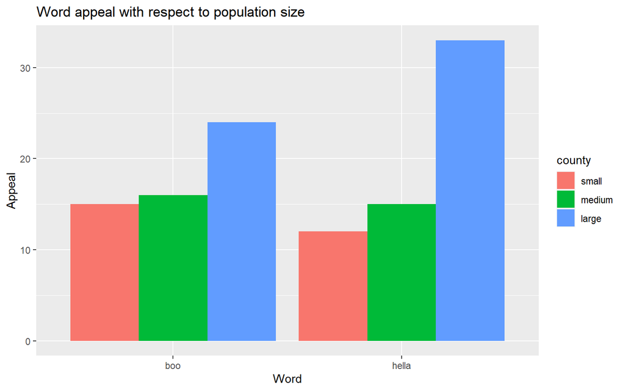

```r
Album_Title %>%
  ggplot(aes(x=word, y=population_appeal)) + geom_col(aes(fill=county), position = 'dodge') + labs(x = "Word", y = "Appeal") + ggtitle('Word appeal with respect to population size')
```

- We have considered words boo and hella from the title as hotline and bling are not present in the dataset. As we can interpret from the graph that the word **hella** is most popular in the county with large population. Hence, anyone trying to create an album should go with the name **Hella Bling**